# Meta-analysis: Split-half reliability of the Serial Reaction Time task

### Sensitivity analysis

```r
#combine effect sizes with different correlation sizes

compute_sensitivity.DS <- function(cor, vi, Study) {
  # construct approx V matrix assuming r=0.6 for the sampling errors
  V.DS <- impute_covariance_matrix(Data.DS$vi, cluster=Data.DS$exp, r=cor)

  # fit multivariate model
  res.DS.sen <- rma.mv(yi, V.DS, random = ~ 1 | Study/exp/obs, data=Data.DS)
  res.DS.sen

}

results.DS = list()
for (cor in  seq(.1, 1,.2))  {
    results.DS[[as.character(cor)]] = compute_sensitivity.DS(cor, vi, Study)
  }

print(results.DS)
```

```
## $`0.1`
##
## Multivariate Meta-Analysis Model (k = 26; method: REML)
##
## Variance Components:
##
##             estim    sqrt  nlvls  fixed         factor
## sigma^2.1  0.0000  0.0000     12     no          Study
## sigma^2.2  0.0731  0.2703     16     no      Study/exp
## sigma^2.3  0.0306  0.1749     26     no  Study/exp/obs
##
## Test for Heterogeneity:
## Q(df = 25) = 202.5348, p-val < .0001
##
## Model Results:
##
## estimate      se    zval    pval   ci.lb   ci.ub
##   0.7405  0.0818  9.0490  <.0001  0.5801  0.9009  ***
##
## ---
## Signif. codes:  0 '***' 0.001 '**' 0.01 '*' 0.05 '.' 0.1 ' ' 1
##
##
## $`0.3`
##
## Multivariate Meta-Analysis Model (k = 26; method: REML)
##
## Variance Components:
##
##             estim    sqrt  nlvls  fixed         factor
## sigma^2.1  0.0000  0.0000     12     no          Study
## sigma^2.2  0.0685  0.2616     16     no      Study/exp
## sigma^2.3  0.0348  0.1865     26     no  Study/exp/obs
##
## Test for Heterogeneity:
## Q(df = 25) = 199.1272, p-val < .0001
##
## Model Results:
##
## estimate      se    zval    pval   ci.lb   ci.ub
```

[output cut: 58 more lines]

```
##             estim    sqrt  nlvls  fixed         factor
## sigma^2.1  0.0000  0.0000     12     no          Study
## sigma^2.2  0.0539  0.2321     16     no      Study/exp
## sigma^2.3  0.0484  0.2199     26     no  Study/exp/obs
##
## Test for Heterogeneity:
## Q(df = 25) = 406.9114, p-val < .0001
##
## Model Results:
##
## estimate      se    zval    pval   ci.lb   ci.ub
##   0.7402  0.0809  9.1493  <.0001  0.5816  0.8988  ***
##
## ---
## Signif. codes:  0 '***' 0.001 '**' 0.01 '*' 0.05 '.' 0.1 ' ' 1
```

## Multivariate model with covariance matrix - Only one measure per session/per study - without Oliveira et al.

We removed the studies conducted by Oliveira et al. because they contributed a lot of entries to the meta-analysis, thus by removing their results, we were able to assess whether their findings were influencing the overall estimates

```r
Data.DS.red <- Data.DS[Data.DS$Authors != "Oliveira et al.",]

# construct approx V matrix assuming r=0.6 for the sampling errors
V.DS.red <- impute_covariance_matrix(Data.DS.red$vi, cluster=Data.DS.red$exp, r=0.6)

# fit multilevel model with nested obs within exp and exp within study
res2.DS.red <- rma.mv(yi, V.DS.red, random = ~ 1 | Study/exp/obs, data=Data.DS.red)
res2.DS.red
```

```
##
## Multivariate Meta-Analysis Model (k = 14; method: REML)
##
## Variance Components:
##
##             estim    sqrt  nlvls  fixed         factor
## sigma^2.1  0.0000  0.0000     10     no          Study
## sigma^2.2  0.1004  0.3169     11     no      Study/exp
## sigma^2.3  0.0547  0.2338     14     no  Study/exp/obs
##
## Test for Heterogeneity:
## Q(df = 13) = 176.4439, p-val < .0001
##
## Model Results:
##
## estimate      se    zval    pval   ci.lb   ci.ub
##   0.7738  0.1215  6.3692  <.0001  0.5357  1.0119  ***
##
## ---
## Signif. codes:  0 '***' 0.001 '**' 0.01 '*' 0.05 '.' 0.1 ' ' 1
```

```r
#check fit
par(mfrow=c(2,2))
profile(res2.DS.red)
```

```
## Profiling sigma2 = 1
```

```
## Profiling sigma2 = 2
```

```
## Profiling sigma2 = 3
```

```r
# compute average odds ratio (and corresponding 95% CI/PI)
predict(res2.DS.red, trans = transf.ztor, digits=2)
```

```
##
##  pred ci.lb ci.ub pi.lb pi.ub
##  0.65  0.49  0.77 -0.03  0.92
```

```r
# RVE standard errors - guards agains model misspecification
coef_test(res2.DS.red, vcov="CR2", cluster= Data.DS.red$Study)
```

```
##    Coef. Estimate    SE t-stat d.f. (Satt) p-val (Satt) Sig.
##  intrcpt    0.774 0.114   6.81        7.79       <0.001  ***
```

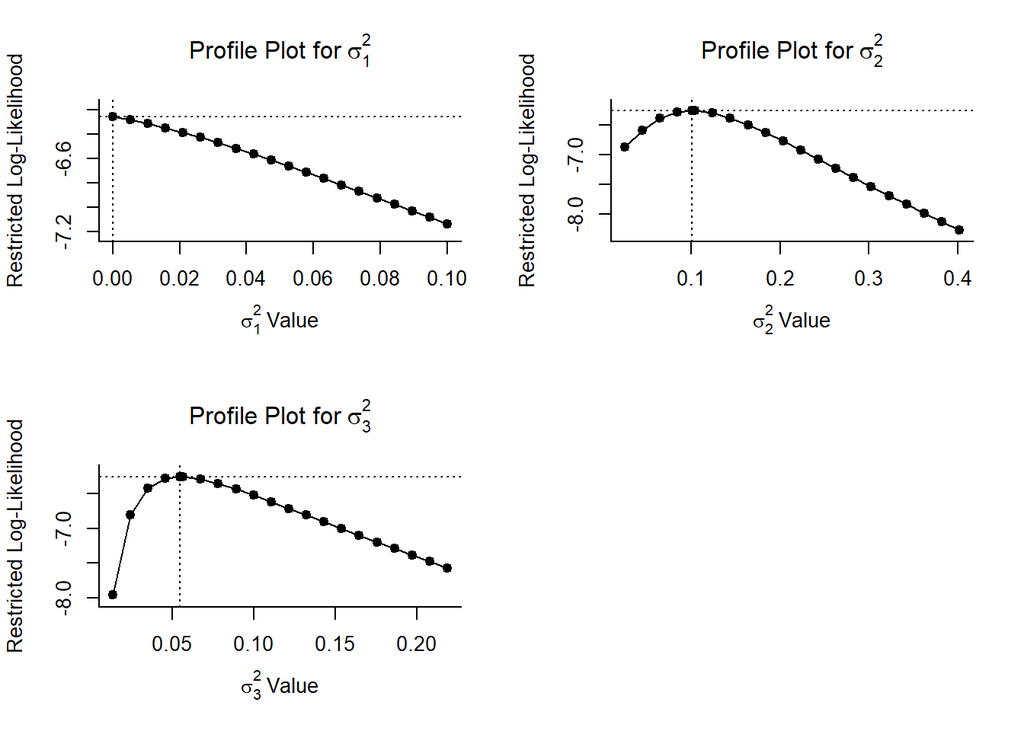

## Multivariate model with covariance matrix - All data

```r
# construct approx V matrix assuming r=0.6 for the sampling errors
V <- impute_covariance_matrix(Data$vi, cluster=Data$exp, r=0.6)

# fit multilevel model
res.ml <- rma.mv(yi, V, random = ~ 1 | Study/obs, data= Data)
res.ml
```

```
##
## Multivariate Meta-Analysis Model (k = 38; method: REML)
##
## Variance Components:
##
##             estim    sqrt  nlvls  fixed     factor
## sigma^2.1  0.0119  0.1089     12     no      Study
## sigma^2.2  0.0864  0.2940     38     no  Study/obs
##
## Test for Heterogeneity:
## Q(df = 37) = 344.6988, p-val < .0001
##
## Model Results:
##
## estimate      se     zval    pval   ci.lb   ci.ub
##   0.7718  0.0741  10.4202  <.0001  0.6267  0.9170  ***
##
## ---
## Signif. codes:  0 '***' 0.001 '**' 0.01 '*' 0.05 '.' 0.1 ' ' 1
```

```r
# fit multilevel model with nested obs within exp and exp within study
res2 <- rma.mv(yi, V, random = ~ 1 | Study/exp/obs, data=Data)
res2
```

```
##
## Multivariate Meta-Analysis Model (k = 38; method: REML)
##
## Variance Components:
##
##             estim    sqrt  nlvls  fixed         factor
## sigma^2.1  0.0000  0.0000     12     no          Study
## sigma^2.2  0.0544  0.2332     16     no      Study/exp
## sigma^2.3  0.0619  0.2487     38     no  Study/exp/obs
##
## Test for Heterogeneity:
## Q(df = 37) = 344.6988, p-val < .0001
##
## Model Results:
##
## estimate      se    zval    pval   ci.lb   ci.ub
##   0.7878  0.0811  9.7112  <.0001  0.6288  0.9468  ***
##
## ---
## Signif. codes:  0 '***' 0.001 '**' 0.01 '*' 0.05 '.' 0.1 ' ' 1
```

```r
anova(res.ml, res2) #no significant difference in fit
```

```
##
##         df     AIC     BIC    AICc   logLik    LRT   pval       QE
## Full     4 30.6488 37.0925 31.8988 -11.3244               344.6988
## Reduced  3 31.3960 36.2287 32.1233 -12.6980 2.7472 0.0974 344.6988
```

```r
#check fit
par(mfrow=c(2,2))
profile(res2)
```

```
## Profiling sigma2 = 1
```

```
## Profiling sigma2 = 2
```

```
## Profiling sigma2 = 3
```

```r
# compute average odds ratio (and corresponding 95% CI/PI)
predict(res2, trans = transf.ztor, digits=2)
```

```
##
##  pred ci.lb ci.ub pi.lb pi.ub
##  0.66  0.56  0.74  0.10  0.90
```

```r
# RVE standard errors - guards agains model misspecification
coef_test(res2, vcov="CR2", cluster= Data$Study)
```

```
##    Coef. Estimate     SE t-stat d.f. (Satt) p-val (Satt) Sig.
##  intrcpt    0.788 0.0731   10.8         5.8       <0.001  ***
```

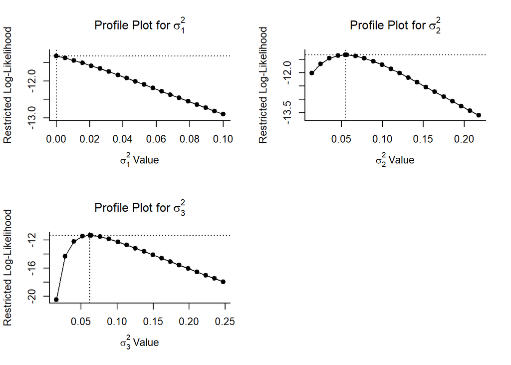

## Multivariate model with covariance matrix - Without Oliveira et al.

```r
red.ml <- Data[Data$Authors != "Oliveira et al.",]

# construct approx V matrix assuming r=0.6 for the sampling errors
V.red <- impute_covariance_matrix(red.ml$vi, cluster=red.ml$exp, r=0.6)

# fit multilevel model with nested obs within exp and exp within study
res2.red <- rma.mv(yi, V.red, random = ~ 1 | Study/exp/obs, data=red.ml)
res2.red
```

```
##
## Multivariate Meta-Analysis Model (k = 14; method: REML)
##
## Variance Components:
##
##             estim    sqrt  nlvls  fixed         factor
## sigma^2.1  0.0000  0.0000     10     no          Study
## sigma^2.2  0.1004  0.3169     11     no      Study/exp
## sigma^2.3  0.0547  0.2338     14     no  Study/exp/obs
##
## Test for Heterogeneity:
## Q(df = 13) = 176.4439, p-val < .0001
##
## Model Results:
##
## estimate      se    zval    pval   ci.lb   ci.ub
##   0.7738  0.1215  6.3692  <.0001  0.5357  1.0119  ***
##
## ---
## Signif. codes:  0 '***' 0.001 '**' 0.01 '*' 0.05 '.' 0.1 ' ' 1
```

```r
# compute average odds ratio (and corresponding 95% CI/PI)
predict(res2.red, trans = transf.ztor, digits=2)
```

```
##
##  pred ci.lb ci.ub pi.lb pi.ub
##  0.65  0.49  0.77 -0.03  0.92
```

```r
# RVE standard errors - guards against model misspecification
coef_test(res2.red, vcov="CR2", cluster= red.ml$Study)
```

```
##    Coef. Estimate    SE t-stat d.f. (Satt) p-val (Satt) Sig.
##  intrcpt    0.774 0.114   6.81        7.79       <0.001  ***
```

### Forest plot

```r
tiff("forest_split-half-all.tiff", width = 1300, height = 1000)

# draw forest plot
forest(res2, header=TRUE, atransf=transf.ztor, refline=coef(res2), ilab.xpos=c(-10,-.5), cex=1.40, xlim = c(-1.3, 3))

### add text with Q-value, dfs, p-value, and I^2 statistic
text(-1.05, -1, pos=4, cex=1.40, bquote(paste("(Q = ",
   .(formatC(res2$QE, digits=2, format="f")), ", df = ", .(res2$k - res2$p),
   ", p = <.001)")))
dev.off()
```

### Sensitivity analysis

```r
#combine effect sizes with different correlation sizes

compute_sensitivity <- function(cor, vi, Study) {
  # construct approx V matrix assuming r=0.6 for the sampling errors
  V <- impute_covariance_matrix(Data$vi, cluster=Data$exp, r=cor)

  # fit multivariate model
  res.sen <- rma.mv(yi, V, random = ~ 1 | Study/exp/obs, data= Data)
  res.sen

}

results = list()
for (cor in  seq(.1, 1,.2))  {
    results[[as.character(cor)]] = compute_sensitivity(cor, vi, Study)
  }

print(results)
```

```
## $`0.1`
##
## Multivariate Meta-Analysis Model (k = 38; method: REML)
##
## Variance Components:
##
##             estim    sqrt  nlvls  fixed         factor
## sigma^2.1  0.0000  0.0000     12     no          Study
## sigma^2.2  0.0664  0.2578     16     no      Study/exp
## sigma^2.3  0.0503  0.2242     38     no  Study/exp/obs
##
## Test for Heterogeneity:
## Q(df = 37) = 272.6922, p-val < .0001
##
## Model Results:
##
## estimate      se    zval    pval   ci.lb   ci.ub
##   0.7877  0.0817  9.6413  <.0001  0.6275  0.9478  ***
##
## ---
## Signif. codes:  0 '***' 0.001 '**' 0.01 '*' 0.05 '.' 0.1 ' ' 1
##
##
## $`0.3`
##
## Multivariate Meta-Analysis Model (k = 38; method: REML)
##
## Variance Components:
##
##             estim    sqrt  nlvls  fixed         factor
## sigma^2.1  0.0000  0.0000     12     no          Study
## sigma^2.2  0.0617  0.2483     16     no      Study/exp
## sigma^2.3  0.0549  0.2342     38     no  Study/exp/obs
##
## Test for Heterogeneity:
## Q(df = 37) = 278.1797, p-val < .0001
##
## Model Results:
##
## estimate      se    zval    pval   ci.lb   ci.ub
```

[output cut: 58 more lines]

```
##             estim    sqrt  nlvls  fixed         factor
## sigma^2.1  0.0000  0.0000     12     no          Study
## sigma^2.2  0.0470  0.2168     16     no      Study/exp
## sigma^2.3  0.0690  0.2627     38     no  Study/exp/obs
##
## Test for Heterogeneity:
## Q(df = 37) = 908.8960, p-val < .0001
##
## Model Results:
##
## estimate      se    zval    pval   ci.lb   ci.ub
##   0.7880  0.0807  9.7588  <.0001  0.6297  0.9462  ***
##
## ---
## Signif. codes:  0 '***' 0.001 '**' 0.01 '*' 0.05 '.' 0.1 ' ' 1
```

## Meta regression

### Measure

```r
Data %>%
  group_by(Measure) %>%
  summarise(
    studies = n_distinct(Study),
    exp = n_distinct(exp),
    effects = n()
  )
```

```
## # A tibble: 2 x 4
##   Measure             studies   exp effects
##   <chr>                 <int> <int>   <int>
## 1 Regression slopes         4     7      14
## 2 RT difference score      10    14      24
```

```r
Data$Measure <- factor(Data$Measure)

res.Measure <- rma.mv(yi, V, mods= ~ Measure -1, random = ~ 1 | Study/exp/obs, data= Data)
res.Measure
```

```
##
## Multivariate Meta-Analysis Model (k = 38; method: REML)
##
## Variance Components:
##
##             estim    sqrt  nlvls  fixed         factor
## sigma^2.1  0.0000  0.0000     12     no          Study
## sigma^2.2  0.0719  0.2681     16     no      Study/exp
## sigma^2.3  0.0497  0.2230     38     no  Study/exp/obs
##
## Test for Residual Heterogeneity:
## QE(df = 36) = 313.1446, p-val < .0001
##
## Test of Moderators (coefficients 1:2):
## QM(df = 2) = 88.3765, p-val < .0001
##
## Model Results:
##
##                             estimate      se    zval    pval   ci.lb   ci.ub
## MeasureRegression slopes      0.9154  0.1076  8.5047  <.0001  0.7045  1.1264
## MeasureRT difference score    0.7322  0.0895  8.1827  <.0001  0.5568  0.9076
##
## MeasureRegression slopes    ***
## MeasureRT difference score  ***
##
## ---
## Signif. codes:  0 '***' 0.001 '**' 0.01 '*' 0.05 '.' 0.1 ' ' 1
```

```r
# guards against model misspecification
coef_test(res.Measure, vcov="CR2", cluster= Data$Study)
```

```
##                       Coef. Estimate     SE t-stat d.f. (Satt) p-val (Satt)
##    MeasureRegression slopes    0.915 0.1582   5.78        2.70       0.0137
##  MeasureRT difference score    0.732 0.0858   8.54        6.13       <0.001
##  Sig.
##     *
##   ***
```

```r
# Robust F-test - comparing whether the all levels are significantly different from zero
Wald_test(res.Measure, constraints = constrain_zero(1:2), vcov = "CR2", tidy = TRUE)
```

```
##  test Fstat df_num df_denom  p_val sig
##   HTZ  31.3      2     1.67 0.0477   *
```

```r
# Robust F-test - not enough datapoints for Ratio
Wald_test(res.Measure, constraints = constrain_pairwise(1:2), vcov = "CR2", tidy = TRUE)
```

```
##                                             hypothesis test Fstat df_num
##  MeasureRT difference score - MeasureRegression slopes  HTZ   1.1      1
##  df_denom p_val sig
##      1.44 0.439
```

### Age

```r
res.age <- rma.mv(yi, V, mods= ~ Age, random = ~ 1 | Study/exp/obs, data= Data)
res.age
```

```
##
## Multivariate Meta-Analysis Model (k = 38; method: REML)
##
## Variance Components:
##
##             estim    sqrt  nlvls  fixed         factor
## sigma^2.1  0.0000  0.0000     12     no          Study
## sigma^2.2  0.0563  0.2373     16     no      Study/exp
## sigma^2.3  0.0624  0.2498     38     no  Study/exp/obs
##
## Test for Residual Heterogeneity:
## QE(df = 36) = 344.1318, p-val < .0001
##
## Test of Moderators (coefficient 2):
## QM(df = 1) = 0.6518, p-val = 0.4195
##
## Model Results:
##
##          estimate      se    zval    pval    ci.lb   ci.ub
## intrcpt    0.8017  0.0838  9.5682  <.0001   0.6374  0.9659  ***
## Age        0.0617  0.0764  0.8074  0.4195  -0.0881  0.2115
##
## ---
## Signif. codes:  0 '***' 0.001 '**' 0.01 '*' 0.05 '.' 0.1 ' ' 1
```

```r
# guards against model misspecification
coef_test(res.age, vcov="CR2", cluster= Data$Study)
```

```
##    Coef. Estimate     SE t-stat d.f. (Satt) p-val (Satt) Sig.
##  intrcpt   0.8017 0.0845   9.49        4.29       <0.001  ***
##      Age   0.0617 0.0611   1.01        5.01        0.359
```

### Trials

```r
res.trials <- rma.mv(yi, V, mods= ~ Trials, random = ~ 1 | Study/exp/obs, data= Data)
res.trials
```

```
##
## Multivariate Meta-Analysis Model (k = 37; method: REML)
##
## Variance Components:
##
##             estim    sqrt  nlvls  fixed         factor
## sigma^2.1  0.0000  0.0000     11     no          Study
## sigma^2.2  0.0601  0.2452     15     no      Study/exp
## sigma^2.3  0.0621  0.2493     37     no  Study/exp/obs
##
## Test for Residual Heterogeneity:
## QE(df = 35) = 338.0171, p-val < .0001
##
## Test of Moderators (coefficient 2):
## QM(df = 1) = 0.0629, p-val = 0.8020
##
## Model Results:
##
##          estimate      se    zval    pval    ci.lb   ci.ub
## intrcpt    0.7680  0.0853  9.0062  <.0001   0.6008  0.9351  ***
## Trials     0.0154  0.0615  0.2507  0.8020  -0.1051  0.1359
##
## ---
## Signif. codes:  0 '***' 0.001 '**' 0.01 '*' 0.05 '.' 0.1 ' ' 1
```

```r
# guards against model misspecification
coef_test(res.trials, vcov="CR2", cluster= Data$Study)
```

```
##    Coef. Estimate     SE t-stat d.f. (Satt) p-val (Satt) Sig.
##  intrcpt   0.7680 0.0783  9.806        5.22       <0.001  ***
##   Trials   0.0154 0.0402  0.383        1.59        0.746
```

### SRTT type

```r
Data %>%
  group_by(SRTT.type) %>%
  summarise(
    studies = n_distinct(Study),
    exp = n_distinct(exp),
    effects = n())
```

```
## # A tibble: 3 x 4
##   SRTT.type     studies   exp effects
##   <chr>           <int> <int>   <int>
## 1 alternating         3     3       3
## 2 deterministic       3     3       3
## 3 probabilistic       6    10      32
```

```r
res.SRTT.type <- rma.mv(yi, V, mods= ~ as.factor(SRTT.type)-1, random = ~ 1 | Study/exp/obs, data= Data)
res.SRTT.type
```

```
##
## Multivariate Meta-Analysis Model (k = 38; method: REML)
##
## Variance Components:
##
##             estim    sqrt  nlvls  fixed         factor
## sigma^2.1  0.0000  0.0000     12     no          Study
## sigma^2.2  0.0685  0.2617     16     no      Study/exp
## sigma^2.3  0.0626  0.2502     38     no  Study/exp/obs
##
## Test for Residual Heterogeneity:
## QE(df = 35) = 309.1784, p-val < .0001
##
## Test of Moderators (coefficients 1:3):
## QM(df = 3) = 82.2937, p-val < .0001
##
## Model Results:
##
##                                    estimate      se    zval    pval   ci.lb
## as.factor(SRTT.type)alternating      0.7791  0.2275  3.4242  0.0006  0.3331
## as.factor(SRTT.type)deterministic    0.7863  0.2224  3.5361  0.0004  0.3505
## as.factor(SRTT.type)probabilistic    0.7892  0.1036  7.6200  <.0001  0.5862
##                                     ci.ub
## as.factor(SRTT.type)alternating    1.2250  ***
## as.factor(SRTT.type)deterministic  1.2222  ***
## as.factor(SRTT.type)probabilistic  0.9922  ***
##
## ---
## Signif. codes:  0 '***' 0.001 '**' 0.01 '*' 0.05 '.' 0.1 ' ' 1
```

```r
# guards against model misspecification
coef_test(res.SRTT.type, vcov="CR2", cluster= Data$Study)
```

```
##                              Coef. Estimate     SE t-stat d.f. (Satt)
##    as.factor(SRTT.type)alternating    0.779 0.2104   3.70        1.93
##  as.factor(SRTT.type)deterministic    0.786 0.1795   4.38        1.99
##  as.factor(SRTT.type)probabilistic    0.789 0.0963   8.19        2.98
##  p-val (Satt) Sig.
##       0.06933    .
##       0.04904    *
##       0.00388   **
```

```r
# compares the levels against zero
Wald_test(res.SRTT.type, constraints = constrain_zero(1:3), vcov = "CR2")
```

```
##  test Fstat df_num df_denom p_val sig
##   HTZ  18.3      3     2.42 0.034   *
```

```r
# compares each level against each other
Wald_test(res.SRTT.type, constraints = constrain_pairwise(1:3), vcov = "CR2")
```

```
## $`as.factor(SRTT.type)deterministic - as.factor(SRTT.type)alternating`
##  test    Fstat df_num df_denom p_val sig
##   HTZ 0.000685      1     3.91  0.98
##
## $`as.factor(SRTT.type)probabilistic - as.factor(SRTT.type)alternating`
##  test   Fstat df_num df_denom p_val sig
##   HTZ 0.00192      1     2.74 0.968
##
## $`as.factor(SRTT.type)probabilistic - as.factor(SRTT.type)deterministic`
##  test    Fstat df_num df_denom p_val sig
##   HTZ 0.000202      1     2.85  0.99
```

### ISI

```r
Data %>%
  group_by(ISI) %>%
  summarise(
    studies = n_distinct(Study),
    exp = n_distinct(exp),
    effects = n())
```

```
## # A tibble: 3 x 4
##     ISI studies   exp effects
##   <int>   <int> <int>   <int>
## 1     0       7     9      25
## 2   250       5     6      12
## 3   500       1     1       1
```

```r
Data.ISI <- Data[Data$ISI != "500",]

# construct approx V matrix assuming r=0.6 for the sampling errors
V.ISI <- impute_covariance_matrix(Data.ISI$vi, cluster=Data.ISI$exp, r=0.6)

res.ISI <- rma.mv(yi, V.ISI, mods= ~ as.factor(ISI)-1, random = ~ 1 | Study/exp/obs, data= Data.ISI)
res.ISI
```

```
##
## Multivariate Meta-Analysis Model (k = 37; method: REML)
##
## Variance Components:
##
##             estim    sqrt  nlvls  fixed         factor
## sigma^2.1  0.0000  0.0000     11     no          Study
## sigma^2.2  0.0600  0.2449     15     no      Study/exp
## sigma^2.3  0.0611  0.2473     37     no  Study/exp/obs
##
## Test for Residual Heterogeneity:
## QE(df = 35) = 287.2864, p-val < .0001
##
## Test of Moderators (coefficients 1:2):
## QM(df = 2) = 81.1108, p-val < .0001
##
## Model Results:
##
##                    estimate      se    zval    pval   ci.lb   ci.ub
## as.factor(ISI)0      0.7159  0.1104  6.4838  <.0001  0.4995  0.9323  ***
## as.factor(ISI)250    0.8483  0.1357  6.2507  <.0001  0.5823  1.1143  ***
##
## ---
## Signif. codes:  0 '***' 0.001 '**' 0.01 '*' 0.05 '.' 0.1 ' ' 1
```

```r
# guards against model misspecification
coef_test(res.ISI, vcov="CR2", cluster= Data.ISI$Study)
```

```
##              Coef. Estimate    SE t-stat d.f. (Satt) p-val (Satt) Sig.
##    as.factor(ISI)0    0.716 0.115   6.20        3.54      0.00509   **
##  as.factor(ISI)250    0.848 0.124   6.86        3.33      0.00451   **
```

```r
Wald_test(res.ISI, constraints = constrain_pairwise(1:2), vcov = "CR2")
```

```
## $`as.factor(ISI)250 - as.factor(ISI)0`
##  test Fstat df_num df_denom p_val sig
##   HTZ 0.573      1     5.11 0.482
```

# Publication bias and Influential/Outliers

## Aggregated effect sizes

### Funnel Plots

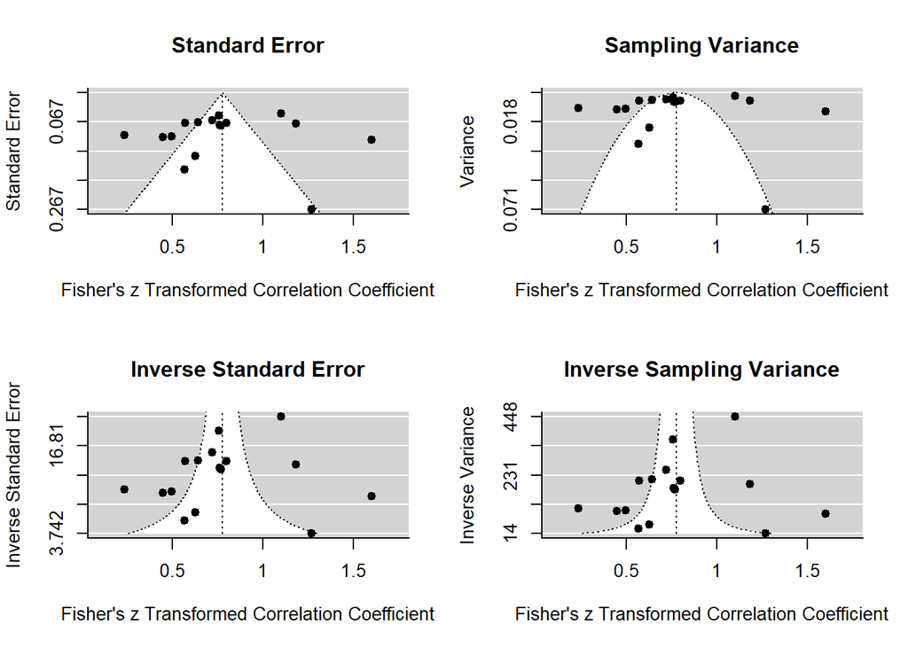

```r
### set up 2x2 array for plotting
par(mfrow=c(2,2))

### draw funnel plots
funnel(res.agg, main="Standard Error")
funnel(res.agg, yaxis="vi", main="Sampling Variance")
funnel(res.agg, yaxis="seinv", main="Inverse Standard Error")
funnel(res.agg, yaxis="vinv", main="Inverse Sampling Variance")
```

```r
dev.off()
```

```r
### funnel plot
funnel(res.agg, xlab = "Correlation coefficient")

### create contour enhanced funnel plot (with funnel centered at 0)
funnel(res.agg, level=c(90, 95, 99), shade=c("white", "gray55", "gray75"), refline=0, legend=TRUE)
```

[output not shown]

### Egger’s regression test/ PET-PEESE procedure

```r
# regression test for funnel plot asymmetry
regtest(res.agg) # uses the SEs as predictor by default
```

```
##
## Regression Test for Funnel Plot Asymmetry
##
## Model:     mixed-effects meta-regression model
## Predictor: standard error
##
## Test for Funnel Plot Asymmetry: z = 0.3810, p = 0.7032
## Limit Estimate (as sei -> 0):   b = 0.7140 (CI: 0.3432, 1.0849)
```

```r
regtest(res.agg, predictor="vi") # use the variances as predictor
```

```
##
## Regression Test for Funnel Plot Asymmetry
##
## Model:     mixed-effects meta-regression model
## Predictor: sampling variance
##
## Test for Funnel Plot Asymmetry: z = 0.6934, p = 0.4881
## Limit Estimate (as vi -> 0):    b = 0.7322 (CI: 0.5197, 0.9447)
```

### Rank correlation test

```r
#Tests for bias
ranktest(res.agg, exact = FALSE)
```

```
##
## Rank Correlation Test for Funnel Plot Asymmetry
##
## Kendall's tau = -0.0667, p = 0.7187
```

### Outlier/influential points detection

```r
par("mar")
```

```
## [1] 5.1 4.1 4.1 2.1
```

```r
### calculate influence diagnostics
inf <- influence(res.agg)

# save influential outlier case numbers in vector
which(inf$is.infl == "TRUE")
```

```
## [1] 1
```

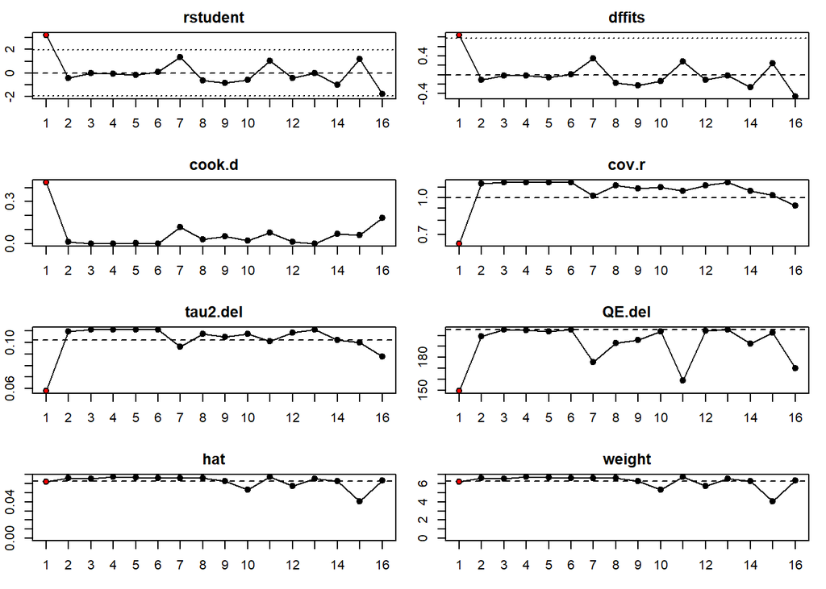

```r
### plot the influence diagnostics
plot(inf)
```

## All effect sizes

### Funnel Plots

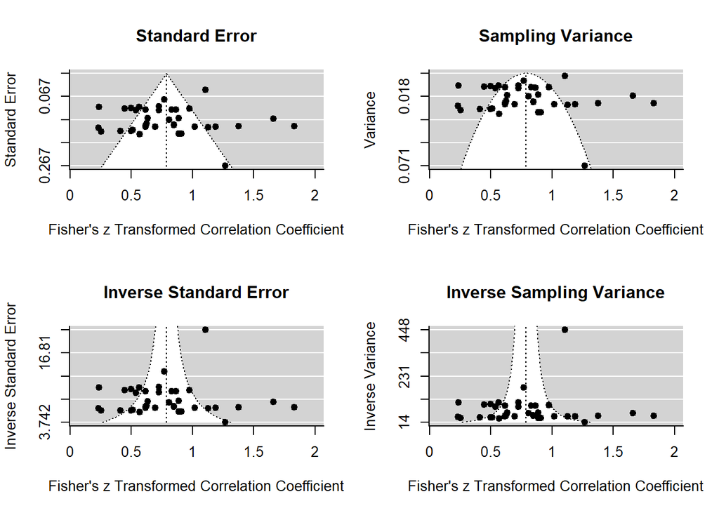

```r
### set up 2x2 array for plotting
par(mfrow=c(2,2))

### draw funnel plots
funnel(res2, main="Standard Error")
funnel(res2, yaxis="vi", main="Sampling Variance")
funnel(res2, yaxis="seinv", main="Inverse Standard Error")
funnel(res2, yaxis="vinv", main="Inverse Sampling Variance")
```

```r
dev.off()
```

```r
png("funnel.split-half.png", width = 1300, height = 700)
par(mfrow=c(1,2))

### funnel plot
fp1 <- funnel(res2, back = "white")

### create contour enhanced funnel plot (with funnel centered at 0)
fp2<- funnel(res2, level=c(90, 95, 99), shade=c("white", "orange", "red"), refline=0, legend = TRUE, back = "white")
dev.off()
```

### Egger’s regression test

```r
# run the regression test (with Vis as predictor) manually

#Reduced model
res.PET <- rma.mv(yi, vi, mods = ~ sei, random = ~ 1 | Study/exp, data=Data.DS)
res.PET
```

```
##
## Multivariate Meta-Analysis Model (k = 26; method: REML)
##
## Variance Components:
##
##             estim    sqrt  nlvls  fixed     factor
## sigma^2.1  0.0000  0.0000     12     no      Study
## sigma^2.2  0.0997  0.3158     16     no  Study/exp
##
## Test for Residual Heterogeneity:
## QE(df = 24) = 196.6463, p-val < .0001
##
## Test of Moderators (coefficient 2):
## QM(df = 1) = 1.1647, p-val = 0.2805
##
## Model Results:
##
##          estimate      se    zval    pval    ci.lb   ci.ub
## intrcpt    0.4971  0.2374  2.0938  0.0363   0.0318  0.9624  *
## sei        1.9143  1.7738  1.0792  0.2805  -1.5622  5.3908
##
## ---
## Signif. codes:  0 '***' 0.001 '**' 0.01 '*' 0.05 '.' 0.1 ' ' 1
```

```r
#Full model
res.ml.PET <- rma.mv(yi, V, mods = ~ sei, random = ~ 1 | Study/exp/obs, data=Data)
res.ml.PET
```

```
##
## Multivariate Meta-Analysis Model (k = 38; method: REML)
##
## Variance Components:
##
##             estim    sqrt  nlvls  fixed         factor
## sigma^2.1  0.0000  0.0000     12     no          Study
## sigma^2.2  0.0557  0.2361     16     no      Study/exp
## sigma^2.3  0.0622  0.2494     38     no  Study/exp/obs
##
## Test for Residual Heterogeneity:
## QE(df = 36) = 336.8985, p-val < .0001
##
## Test of Moderators (coefficient 2):
## QM(df = 1) = 0.9138, p-val = 0.3391
##
## Model Results:
##
##          estimate      se    zval    pval    ci.lb   ci.ub
## intrcpt    0.5621  0.2499  2.2490  0.0245   0.0722  1.0519  *
## sei        1.7738  1.8555  0.9559  0.3391  -1.8630  5.4106
##
## ---
## Signif. codes:  0 '***' 0.001 '**' 0.01 '*' 0.05 '.' 0.1 ' ' 1
```

### Influential points

#### Effect size level

##### All data

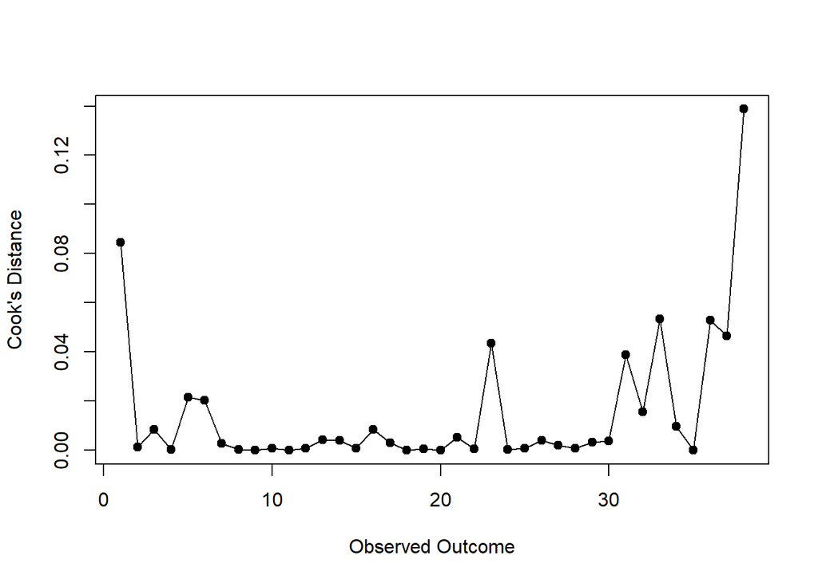

```r
CD2 <- cooks.distance(res2)
plot(CD2, type="o", pch=19, xlab="Observed Outcome", ylab="Cook's Distance")
```

```r
print(CD2)
```

```
##                     West et al., 2021.1                     West et al., 2021.2
##                            8.450011e-02                            1.269421e-03
##                     West et al., 2021.3                     West et al., 2021.4
##                            8.499844e-03                            2.598356e-04
##                     West et al., 2018.1                     West et al., 2018.2
##                            2.168925e-02                            2.034234e-02
##            Oliveira et al., submitted.1            Oliveira et al., submitted.2
##                            2.806894e-03                            4.323520e-04
##            Oliveira et al., submitted.3            Oliveira et al., submitted.4
##                            2.080189e-04                            7.973709e-04
##            Oliveira et al., submitted.5            Oliveira et al., submitted.6
##                            2.180277e-04                            8.190550e-04
##            Oliveira et al., submitted.7            Oliveira et al., submitted.8
##                            4.302539e-03                            3.940518e-03
##            Oliveira et al., submitted.9           Oliveira et al., submitted.10
##                            8.642995e-04                            8.374996e-03
##           Oliveira et al., submitted.11           Oliveira et al., submitted.12
##                            3.153842e-03                            4.825016e-05
##           Oliveira et al., submitted.13           Oliveira et al., submitted.14
##                            5.012766e-04                            5.024796e-05
##           Oliveira et al., submitted.15           Oliveira et al., submitted.16
##                            5.404029e-03                            5.524277e-04
##           Oliveira et al., submitted.17           Oliveira et al., submitted.18
##                            4.350374e-02                            3.463138e-04
##                 Oliveira et al., 2022.1                 Oliveira et al., 2022.2
##                            9.100565e-04                            4.062915e-03
##                 Oliveira et al., 2022.3                 Oliveira et al., 2022.4
##                            2.014806e-03                            8.033655e-04
##                 Oliveira et al., 2022.5                 Oliveira et al., 2022.6
##                            3.270303e-03                            3.906309e-03
##                             Brown, 2010                 Lammertink et al., 2020
##                            3.886718e-02                            1.575604e-02
##       Feldman, Kerr & Streissguth, 1995         van Witteloostuijn et al., 2021
##                            5.344118e-02                            9.771442e-03
##                     Farkas et al., 2023                 Buffington et al., 2021
##                            1.144720e-04                            5.291731e-02
## Faretta-Stutenberg & Morgan-Short, 2018                 Iizuka & DeKeyser, 2023
##                            4.657735e-02                            1.387911e-01
```

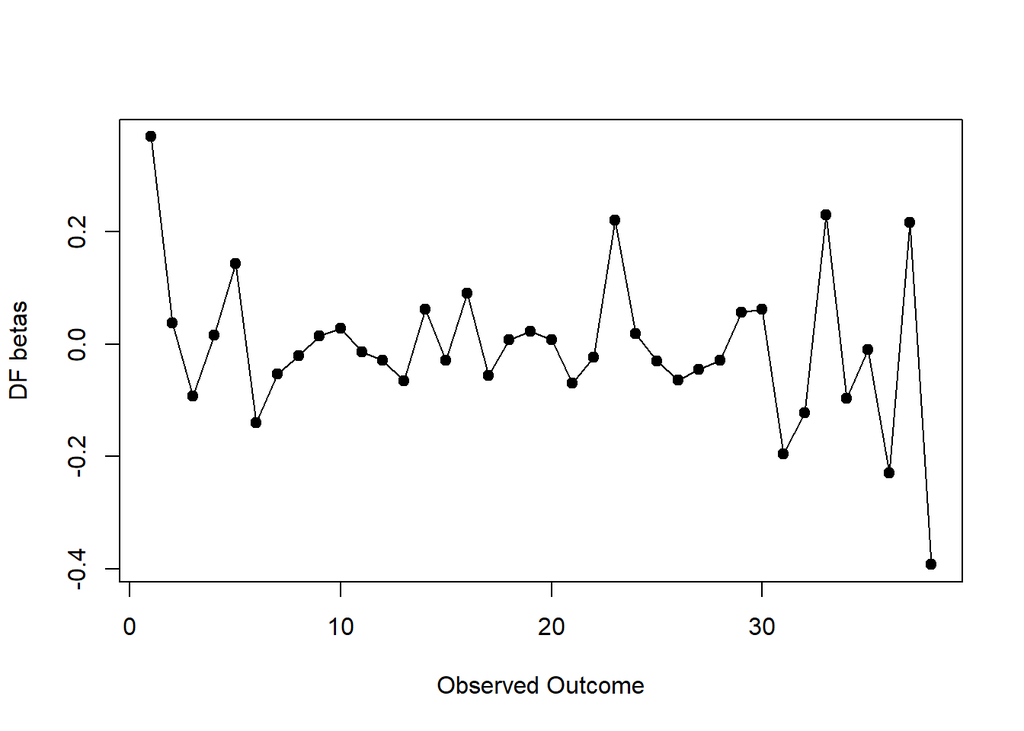

```r
DFbetas2 <- dfbetas(res2)
DFbetas2$scale <- scale(DFbetas2$intrcpt)
plot(DFbetas2$intrcpt, type="o", pch=19, xlab="Observed Outcome", ylab="DF betas")
```

#### Experiment level

##### DS data

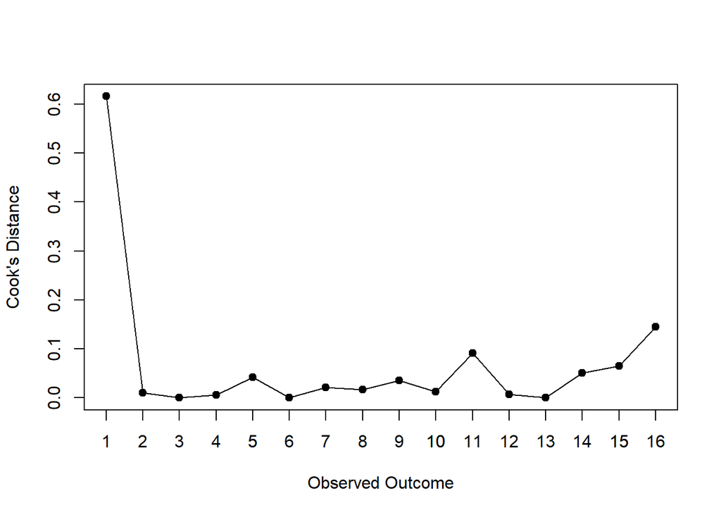

```r
CD.cluster1 <- cooks.distance(res2.DS, cluster = Data.DS$exp)
plot(CD.cluster1, type="o", pch=19, xlab="Observed Outcome", ylab="Cook's Distance")
axis(side=1, at=seq_along(CD.cluster1), labels=as.numeric(names(CD.cluster1)))
```

```r
print(names(CD.cluster1))
```

```
##  [1] "1"  "2"  "3"  "4"  "5"  "6"  "7"  "8"  "9"  "10" "11" "12" "13" "14" "15"
## [16] "16"
```

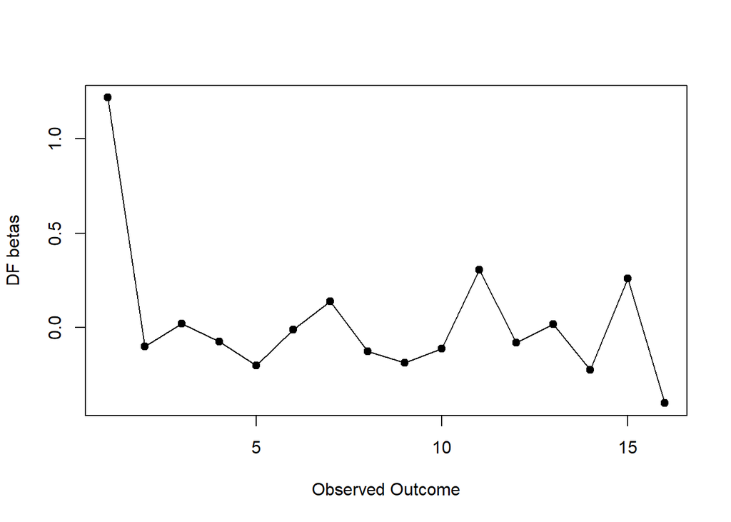

```r
DFbetas.exp1 <- dfbetas(res2.DS, cluster = Data.DS$exp)
DFbetas.exp1$scale <- scale(DFbetas.exp1$intrcpt)
plot(DFbetas.exp1$intrcpt, type="o", pch=19, xlab="Observed Outcome", ylab="DF betas")
```

##### All data

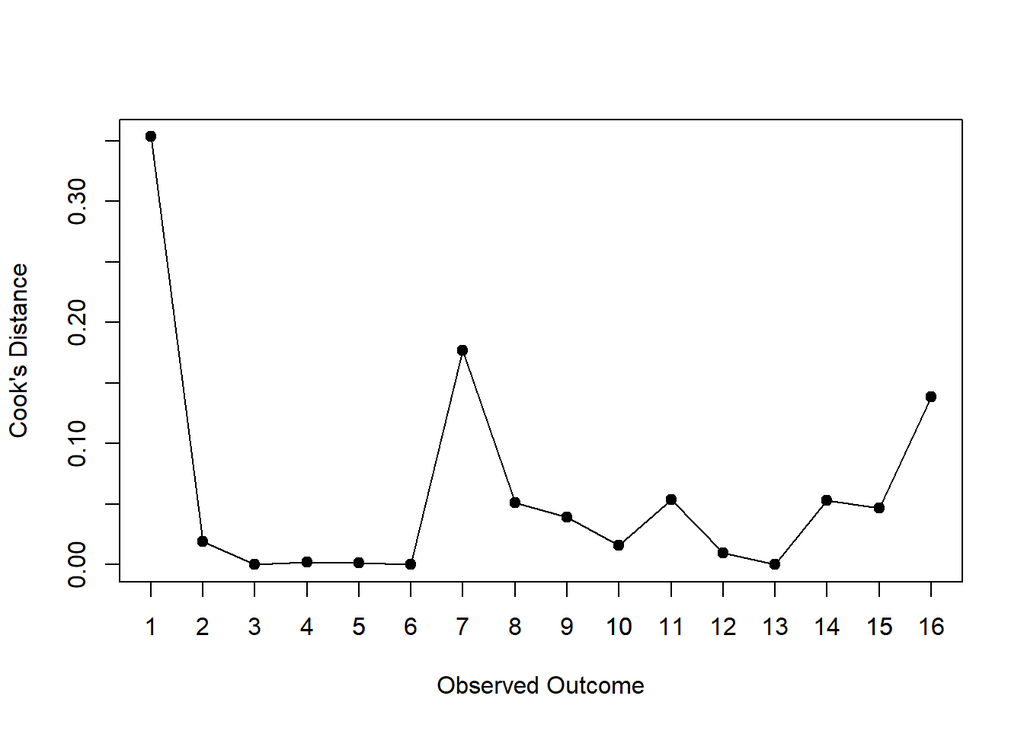

```r
CD.cluster2 <- cooks.distance(res2, cluster = Data$exp)
plot(CD.cluster2, type="o", pch=19, xlab="Observed Outcome", ylab="Cook's Distance")
axis(side=1, at=seq_along(CD.cluster2), labels=as.numeric(names(CD.cluster2)))
```

```r
print(names(CD.cluster2))
```

```
##  [1] "1"  "2"  "3"  "4"  "5"  "6"  "7"  "8"  "9"  "10" "11" "12" "13" "14" "15"
## [16] "16"
```

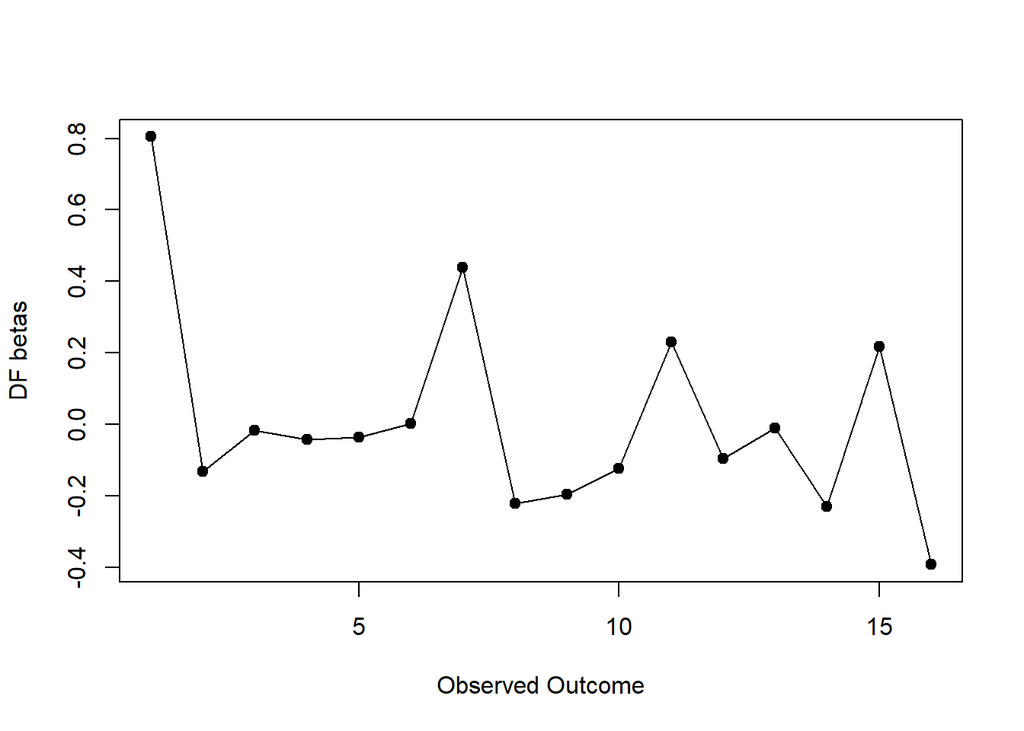

```r
DFbetas.exp2 <- dfbetas(res2, cluster = Data$exp)
DFbetas.exp2$scale <- scale(DFbetas.exp2$intrcpt)
plot(DFbetas.exp2$intrcpt, type="o", pch=19, xlab="Observed Outcome", ylab="DF betas")
```

#### Study level

##### DS data

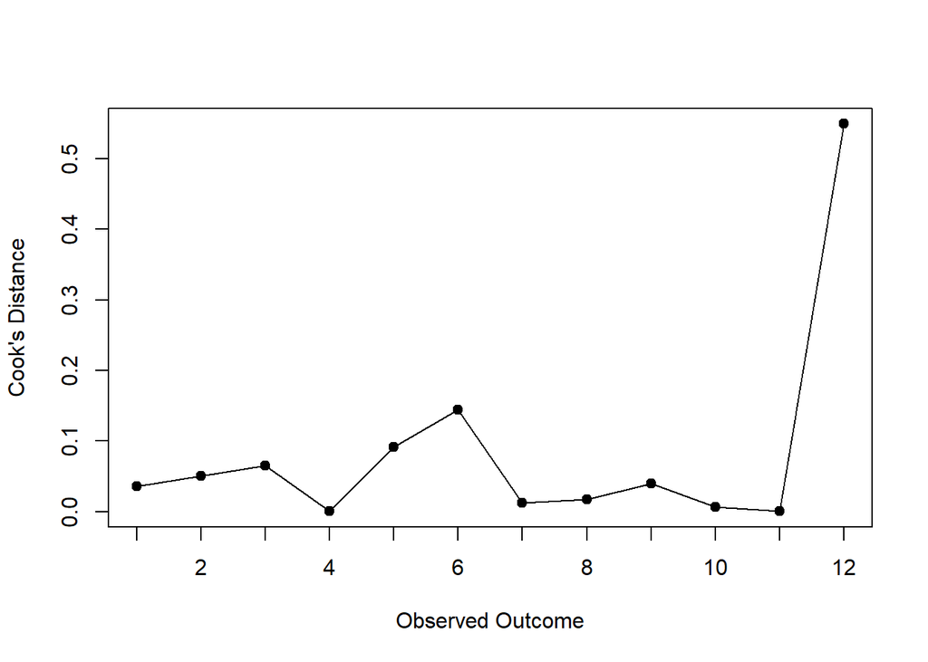

```r
CD.cluster3 <- cooks.distance(res2.DS, cluster = Data.DS$Study)
plot(CD.cluster3, type="o", pch=19, xlab="Observed Outcome", ylab="Cook's Distance")
axis(side=1, at=seq_along(CD.cluster3), labels=as.numeric(names(CD.cluster3)))
```

```r
print(names(CD.cluster3))
```

```
##  [1] "Brown (2010)"
##  [2] "Buffington et al. (2021)"
##  [3] "Faretta-Stutenberg & Morgan-Short (2018)"
##  [4] "Farkas et al. (2023)"
##  [5] "Feldman et al. (1995)"
##  [6] "Iizuka & DeKeyser (2023)"
##  [7] "Lammertink et al. (2020)"
##  [8] "Oliveira et al. (in prep)"
##  [9] "Oliveira et al. (submitted)"
## [10] "van Witteloostuijn et al. (2021)"
## [11] "West et al. (2018)"
## [12] "West et al. (2021)"
```

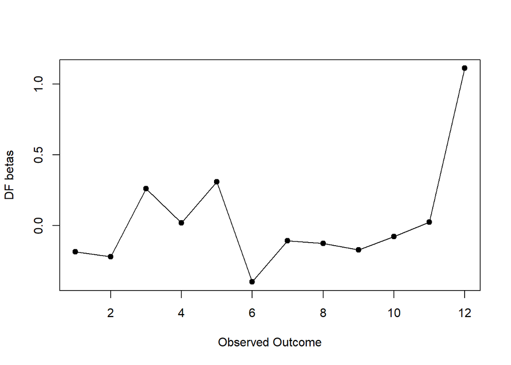

```r
DFbetas.study3 <- dfbetas(res2.DS, cluster = Data.DS$Study)
DFbetas.study3$scale <- scale(DFbetas.study3$intrcpt)
plot(DFbetas.study3$intrcpt, type="o", pch=19, xlab="Observed Outcome", ylab="DF betas")
```

##### All data

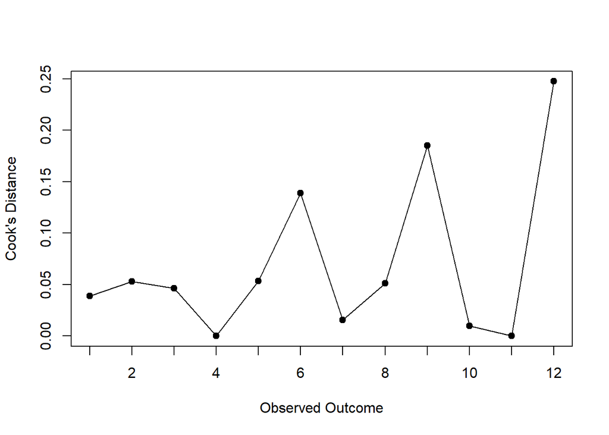

```r
CD.cluster4 <- cooks.distance(res2, cluster = Data$Study)
plot(CD.cluster4, type="o", pch=19, xlab="Observed Outcome", ylab="Cook's Distance")
axis(side=1, at=seq_along(CD.cluster4), labels=as.numeric(names(CD.cluster4)))
```

```r
print(names(CD.cluster4))
```

```
##  [1] "Brown (2010)"
##  [2] "Buffington et al. (2021)"
##  [3] "Faretta-Stutenberg & Morgan-Short (2018)"
##  [4] "Farkas et al. (2023)"
##  [5] "Feldman et al. (1995)"
##  [6] "Iizuka & DeKeyser (2023)"
##  [7] "Lammertink et al. (2020)"
##  [8] "Oliveira et al. (in prep)"
##  [9] "Oliveira et al. (submitted)"
## [10] "van Witteloostuijn et al. (2021)"
## [11] "West et al. (2018)"
## [12] "West et al. (2021)"
```

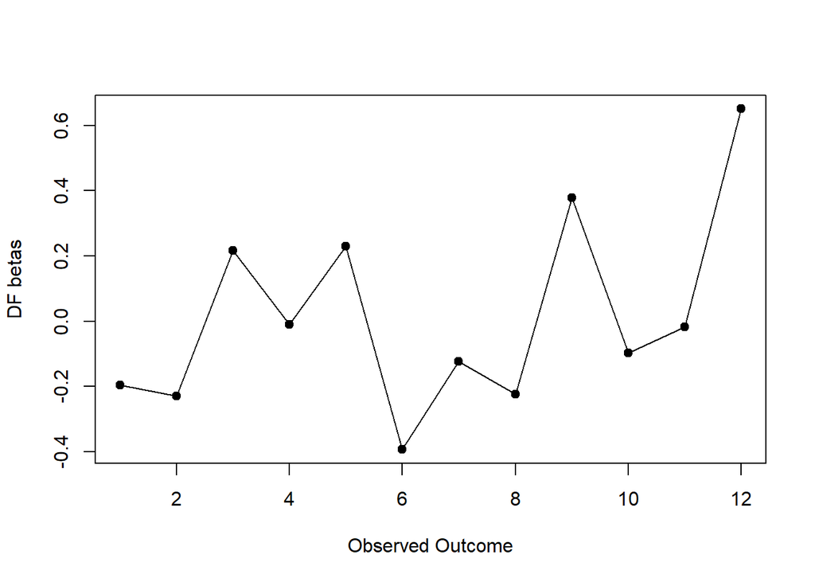

```r
DFbetas.study4 <- dfbetas(res2, cluster = Data$Study)
DFbetas.study4$scale <- scale(DFbetas.study4$intrcpt)
plot(DFbetas.study4$intrcpt, type="o", pch=19, xlab="Observed Outcome", ylab="DF betas")
```

### Outliers

#### DS data

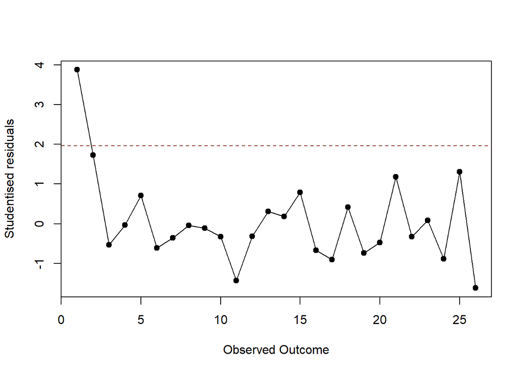

```
## integer(0)
```

```r
sr <- rstudent(res2.DS)

plot(sr$z, type="o", pch=19, xlab="Observed Outcome", ylab="Studentised residuals") + abline(h = 1.96, lty = 2, col = "tomato4")
```

```r
print(sr$slab)
```

```
##  [1] "West et al., 2021.1"
##  [2] "West et al., 2021.2"
##  [3] "West et al., 2021.3"
##  [4] "West et al., 2021.4"
##  [5] "West et al., 2018.1"
##  [6] "West et al., 2018.2"
##  [7] "Oliveira et al., submitted.1"
##  [8] "Oliveira et al., submitted.2"
##  [9] "Oliveira et al., submitted.5"
## [10] "Oliveira et al., submitted.6"
## [11] "Oliveira et al., submitted.7"
## [12] "Oliveira et al., submitted.11"
## [13] "Oliveira et al., submitted.12"
## [14] "Oliveira et al., submitted.15"
## [15] "Oliveira et al., submitted.16"
## [16] "Oliveira et al., 2022.1"
## [17] "Oliveira et al., 2022.3"
## [18] "Oliveira et al., 2022.5"
## [19] "Brown, 2010"
## [20] "Lammertink et al., 2020"
## [21] "Feldman, Kerr & Streissguth, 1995"
## [22] "van Witteloostuijn et al., 2021"
## [23] "Farkas et al., 2023"
## [24] "Buffington et al., 2021"
## [25] "Faretta-Stutenberg & Morgan-Short, 2018"
## [26] "Iizuka & DeKeyser, 2023"
```

#### All data

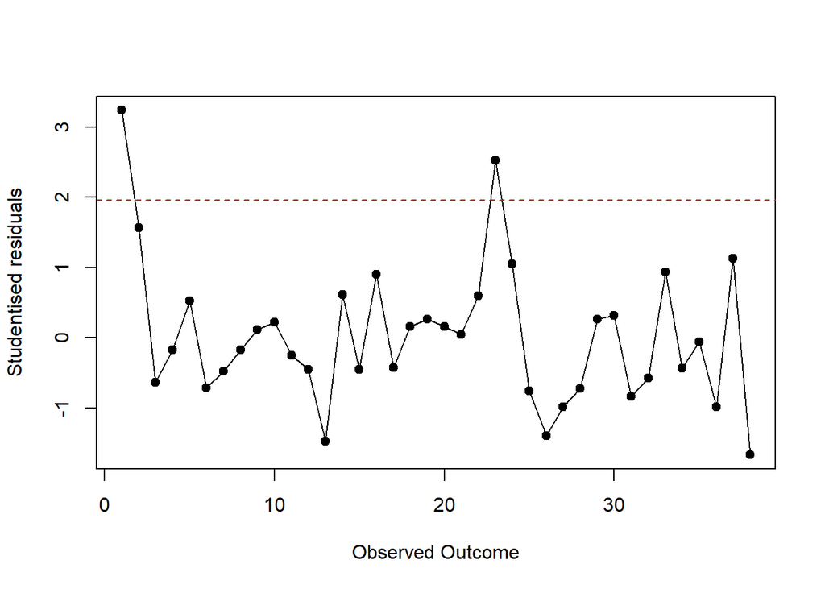

```
## integer(0)
```

```r
sr2 <- rstudent(res2)

plot(sr2$z, type="o", pch=19, xlab="Observed Outcome", ylab="Studentised residuals") + abline(h = 1.96, lty = 2, col = "tomato4")
```

```r
print(sr2$slab)
```

```
##  [1] "West et al., 2021.1"
##  [2] "West et al., 2021.2"
##  [3] "West et al., 2021.3"
##  [4] "West et al., 2021.4"
##  [5] "West et al., 2018.1"
##  [6] "West et al., 2018.2"
##  [7] "Oliveira et al., submitted.1"
##  [8] "Oliveira et al., submitted.2"
##  [9] "Oliveira et al., submitted.3"
## [10] "Oliveira et al., submitted.4"
## [11] "Oliveira et al., submitted.5"
## [12] "Oliveira et al., submitted.6"
## [13] "Oliveira et al., submitted.7"
## [14] "Oliveira et al., submitted.8"
## [15] "Oliveira et al., submitted.9"
```

[output cut: 23 more lines]

# References

Viechtbauer, W. (2021). An overview of the metafor package with some interesting applications. Annual Meeting of the Society for Research Synthesis Methodology, Online. https://www.wvbauer.com/doku.php/presentations

https://wviechtb.github.io/metafor/reference/rma.mv.html

Assink, M., & Wibbelink, C. J. M. (2016). Fitting three-level meta-analytic models in R: A step-by-step tutorial. The Quantitative Methods for Psychology, 12(3), 154–174. https://doi.org/10.20982/tqmp.12.3.p154

[^1]: OSF page: https://osf.io/dpmfc/